# Models for analysis of fatigue score in LongCOVID/VASCO studies

Things to address

1. How to fit smooth splines to the data (without fixing the location knots)?
2. How to adjust for repeated measurements within persons?
3. How to test for difference in fatigue scores between groups (COVID variant or sex) for different time points after infection?
4. How to adjust the models for seasonal effects?

## 0. Preparations

#### Initialize

```r
# load packages
library(tidyverse)
# gamm4 also attaches mgcv and lme4
library(gamm4)
```

#### Load data

```r
# import data
VASCO_data_org <- readRDS(
  file = file.path(here::here(), "data/20230609_data_VASCO_CIS.rds")
)
```

#### Transform data

```r
# transform data
VASCO_data <- VASCO_data_org |>
  # column names in lower case
  rename_with(
    .fn = tolower
  ) |>
  mutate(
    # person_id as factor
    person_id = studyid |>
      factor(),
    studyid = NULL,
    # fatigue_score
    fatigue_score = cis_subj_fat,
    cis_subj_fat = NULL,
    # COVID variant as factor
    variant = variant |>
      word(start = 1) |>
      factor()
  )

# restrict to COVID variants Delta & Omicron
VASCO_data_omicron_delta <- VASCO_data |>
  filter(variant %in% c("Delta", "Omicron")) |>
  droplevels()

# give summary
VASCO_data_omicron_delta |> summary()
```

```
       age_group       geslacht                         medisch_risicogroep
 18-59 years:33034   Anders:   31   Without medical risk condition:44789
 60-85 years:27380   Man   :20825   With medical risk condition   :15625
                     Vrouw :39558




     vaccinatiestatus infectie_datum         invuldatum
 Booster vacc:52330   Min.   :2021-07-12   Min.   :2021-05-17
 Full vacc   : 5874   1st Qu.:2022-02-26   1st Qu.:2022-03-14
 Other       :  282   Median :2022-03-28   Median :2022-06-24
 Unvacc      : 1928   Mean   :2022-05-14   Mean   :2022-07-06
                      3rd Qu.:2022-07-22   3rd Qu.:2022-10-02
                      Max.   :2023-04-07   Max.   :2023-05-07

      time           variant      cis_change_abs       person_id
 Min.   :-90.00   Delta  : 2135   Min.   :-45.000   VS106313:    6
 1st Qu.:-31.00   Omicron:58279   1st Qu.: -4.000   VS119993:    6
 Median : 41.00                   Median :  0.000   VS134861:    6
 Mean   : 52.15                   Mean   :  1.272   VS157058:    6
 3rd Qu.:119.00                   3rd Qu.:  6.000   VS100172:    5
 Max.   :300.00                   Max.   : 48.000   VS100242:    5
                                  NA's   :20447     (Other) :60380
 fatigue_score
 Min.   : 8.00
 1st Qu.:13.00
 Median :20.00
 Mean   :22.79
 3rd Qu.:31.00
 Max.   :56.00
```

## 1. How to fit smooth splines to the data (without fixing the location knots)?

The `gam`function from the `mgcv`package is used to fit smooth splines using the `s` function. See `help(gam)` and `help(s)`. The argument `bs` is used specify the type of spline used. The option `bs = "ps"` makes sure a penalized spline is fitted to the data. Where the smoothness in terms of optimal (effective) degrees of freedom is estimated along with the model fit.

```r
# fixed effects only, P-spline for time
mod_gam_penalized <- gam(
  formula = fatigue_score ~ 1 + s(time, bs = "ps"),
  data = VASCO_data_omicron_delta)

# summary of model fit
mod_gam_penalized |> summary()
```

```
Family: gaussian
Link function: identity

Formula:
fatigue_score ~ 1 + s(time, bs = "ps")

Parametric coefficients:
            Estimate Std. Error t value Pr(>|t|)
(Intercept) 22.79134    0.04938   461.6   <2e-16 ***
---
Signif. codes:  0 '***' 0.001 '**' 0.01 '*' 0.05 '.' 0.1 ' ' 1

Approximate significance of smooth terms:
          edf Ref.df     F p-value
s(time) 8.858  8.987 54.91  <2e-16 ***
---
Signif. codes:  0 '***' 0.001 '**' 0.01 '*' 0.05 '.' 0.1 ' ' 1

R-sq.(adj) =  0.00796   Deviance explained = 0.811%
GCV = 147.33  Scale est. = 147.3     n = 60414
```

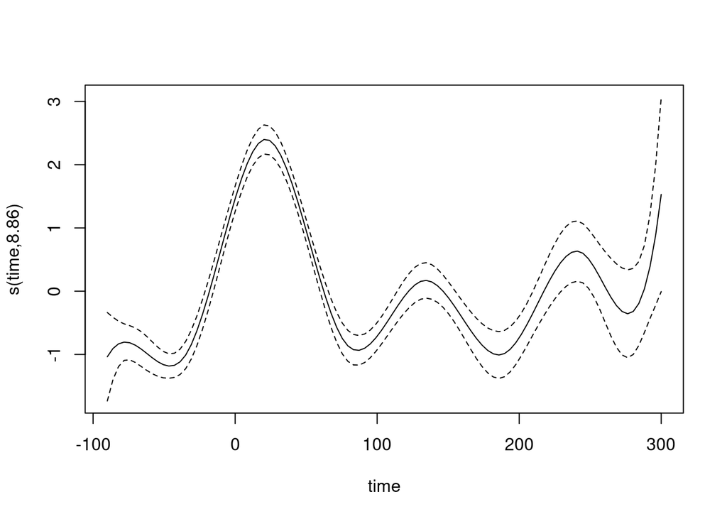

```r
# show the fitted spline
mod_gam_penalized |> plot()
```

The summary shows that the estimated degrees of freedom for the P-spline is 8.86, and this spline is significantly different from 0. The shape of the fitted spline, the confidence limits (and the degrees of freedom) are reflected in the figure.

Note that the smoothness is globally over the `time` domain.

To fit a model with a spline that adapts locally to the data one can use `bs = "ad"` to specify the fit of an adaptive spline.

```r
# fixed effects only, adaptive-spline for time
mod_gam_adaptive <- gam(
  formula = fatigue_score ~ 1 + s(time, bs = "ad"),
  data = VASCO_data_omicron_delta)

# summary of model fit
mod_gam_adaptive |> summary()
```

```
Family: gaussian
Link function: identity

Formula:
fatigue_score ~ 1 + s(time, bs = "ad")

Parametric coefficients:
            Estimate Std. Error t value Pr(>|t|)
(Intercept)  22.7913     0.0493   462.3   <2e-16 ***
---
Signif. codes:  0 '***' 0.001 '**' 0.01 '*' 0.05 '.' 0.1 ' ' 1

Approximate significance of smooth terms:
          edf Ref.df     F p-value
s(time) 22.03  25.53 27.18  <2e-16 ***
---
Signif. codes:  0 '***' 0.001 '**' 0.01 '*' 0.05 '.' 0.1 ' ' 1

R-sq.(adj) =  0.0112   Deviance explained = 1.15%
GCV = 146.88  Scale est. = 146.83    n = 60414
```

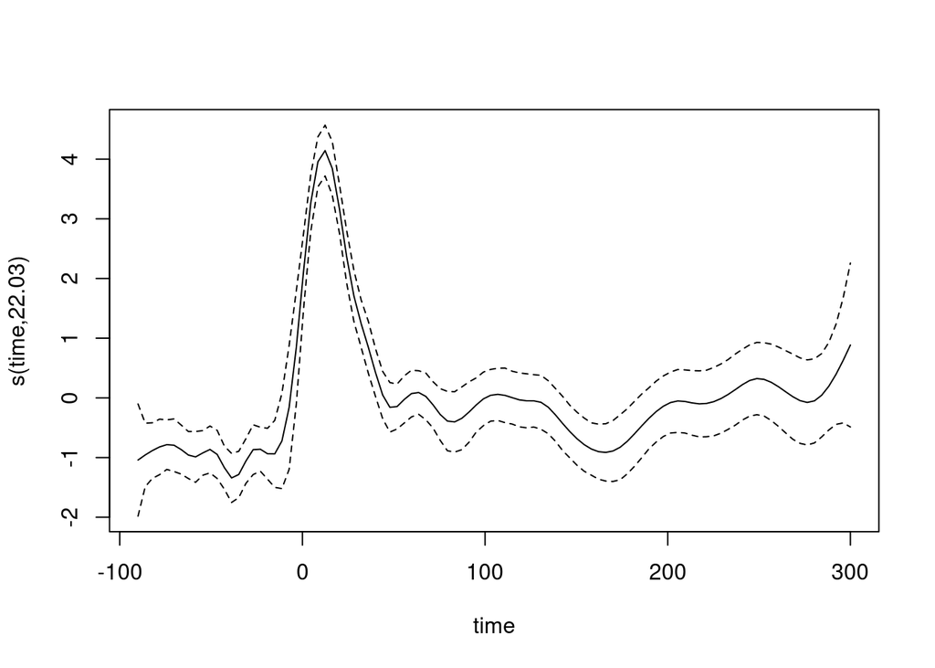

```r
# show the fitted spline
mod_gam_adaptive |> plot()
```

The estimated degrees of freedom is much higher ( 22.03) than in the model with the penalized spline. But also the fit is much better. The AIC is used to judge which of the models fits best to the data:

```r
AIC(mod_gam_penalized, mod_gam_adaptive)
```

```
                        df      AIC
mod_gam_penalized 10.85759 473075.8
mod_gam_adaptive  24.02671 472894.2
```

Clearly the model with the adaptive spline should be preferred.

## 2. How to adjust for repeated measurements within persons?

There are multiple measurements for each individual (`person_id`). One can adjust for the repeated measurements by using mixed models. In `mgcv` one can specify random effects as well, by using the `bs = "re"` option within the `s` function. There are however two drawbacks to this implementation:

1. The combination of an adaptive spline and random effects together in one model is *not* implemented in the `mgcv` framework.
2. The combination of a penalized spline and random effects *is* feasible, but fails to converge in the `gam` implementation. The `gamm4` package uses the mixed model implementation of the `lme4` package and by using the `gamm4` function from this package the model with penalized spline and random effects can be fit.

```r
# Doesn't work/converge.....
# mod_gam_penalized_re <- gam(
#   formula = fatigue_score ~ 1 + s(time, bs = "ps") + s(person_id, bs = "re"),
#   data = VASCO_data_omicron_delta)

mod_gamm4_penalized <- gamm4(
  formula = fatigue_score ~ 1 + s(time, bs = "ps"),
  random = ~(1|person_id),
  REML = FALSE,
  data = VASCO_data_omicron_delta)

# summary of model fit
summary(mod_gamm4_penalized$gam) ## summary of gam
```

```
Family: gaussian
Link function: identity

Formula:
fatigue_score ~ 1 + s(time, bs = "ps")

Parametric coefficients:
            Estimate Std. Error t value Pr(>|t|)
(Intercept) 22.68417    0.07652   296.4   <2e-16 ***
---
Signif. codes:  0 '***' 0.001 '**' 0.01 '*' 0.05 '.' 0.1 ' ' 1

Approximate significance of smooth terms:
          edf Ref.df     F p-value
s(time) 8.667  8.667 181.1  <2e-16 ***
---
Signif. codes:  0 '***' 0.001 '**' 0.01 '*' 0.05 '.' 0.1 ' ' 1

R-sq.(adj) =  0.00719
lmer.REML = 4.4198e+05  Scale est. = 44.254    n = 60414
```

```r
summary(mod_gamm4_penalized$mer) ## underlying mixed model
```

```
Linear mixed model fit by maximum likelihood  ['lmerMod']

      AIC       BIC    logLik  deviance  df.resid
 441992.2  442037.2 -220991.1  441982.2     60409

Scaled residuals:
    Min      1Q  Median      3Q     Max
-4.0132 -0.4998 -0.0996  0.4469  5.0354

Random effects:
 Groups    Name        Variance Std.Dev.
 person_id (Intercept) 103.21   10.159
 Xr        s(time)      13.69    3.700
 Residual               44.25    6.652
Number of obs: 60414, groups:  person_id, 20433; Xr, 8

Fixed effects:
             Estimate Std. Error t value
X(Intercept) 22.68417    0.07652  296.43
Xs(time)Fx1  12.38679    2.99175    4.14

Correlation of Fixed Effects:
            X(Int)
Xs(time)Fx1 0.007
```

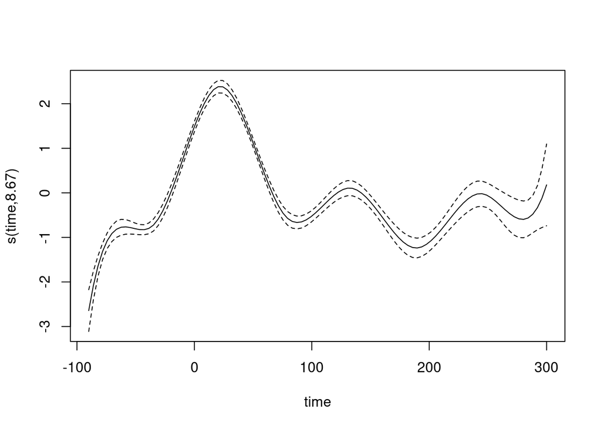

```r
# show the fitted spline
mod_gamm4_penalized$gam |> plot()
```

## 3. How to test for difference in fatigue scores between groups (COVID variant or sex) for different time points after infection?

#### Model fit

In order to test for difference in the predicted outcome between groups, first a model has to be fit that incorporates the interaction between `time`and the group. For example if the interest is in the difference between the two COVID variants over time:

```r
mod_variant_gamm4 <- gamm4(
  formula = fatigue_score ~ variant + s(time, bs = "ps", by = variant),
  random = ~(1|person_id),
  REML = FALSE,
  data = VASCO_data_omicron_delta)
```

#### Predictions

##### prediction data

First make a new data set for which predictions are needed

```r
# next create new data set
VASCO_newdata <- expand_grid(
  time = -90:300
)
```

##### prediction of linear predictor matrix

Based on the fitted model `mod_variant_gamm4` the linear predictor matrix (= `lpmatrix`) of `VASCO_newdata` is obtained.

```r
# linear predictor matrix for variant = Delta
X_lp_delta <- predict(
  object  = mod_variant_gamm4$gam,
  newdata = VASCO_newdata |>
    mutate(variant = "Delta"),
  type = "lpmatrix")

# linear predictor matrix for variant = Omicron
X_lp_omicron <- predict(
  object  = mod_variant_gamm4$gam,
  newdata = VASCO_newdata |>
    mutate(variant = "Omicron"),
  type = "lpmatrix")

# linear predictor matrix of difference
X_lp_difference <- X_lp_delta - X_lp_omicron
```

##### create predicted outcomes

When the predicted lpmatrix is multiplied by the coefficients of the fitted model this gives the predicted outcomes themselves (see also `help(predict.gam)` and the examples therein. Likewise standard errors and confidence limits can be created.

```r
# coefficients of model fit
betas <- coef(mod_variant_gamm4$gam)
# variance covariance matrix
varcov <- mod_variant_gamm4$gam$Vp

# create predictions of difference over time
VASCO_newdata <- VASCO_newdata |>
  mutate(
    # calculate prediction of difference
    pred_difference = X_lp_difference %*% betas,
    # calculate standard errors of prediction of difference
    se_pred_difference =  (X_lp_difference %*% varcov %*% t(X_lp_difference)) |>
      diag() |>
      sqrt(),
    # calculate confidence limits of prediction of difference
    ci_lwr_pred_difference = pred_difference - 1.96 * se_pred_difference,
    ci_upr_pred_difference = pred_difference + 1.96 * se_pred_difference)
```

##### visualize predicted outcomes

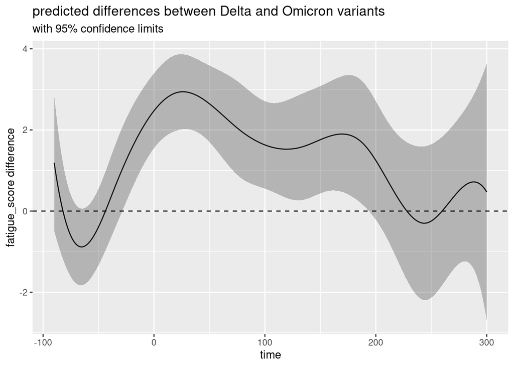

```r
# visualize predicted differences
ggplot(
  data = VASCO_newdata,
  mapping = aes(x = time, y = pred_difference)
) +
  # add predictions
  geom_line() +
  # add confidence bands
  geom_ribbon(
    mapping = aes(
      ymin = ci_lwr_pred_difference,
      ymax = ci_upr_pred_difference),
    alpha = .3) +
  # add reference line at 0
  geom_hline(yintercept = 0, linetype = 2) +
  # add annotations
  labs(
    title ="predicted differences between Delta and Omicron variants",
    subtitle = "with 95% confidence limits",
    y = "fatigue_score difference"
  )
```

The same can be done for difference between sexes:

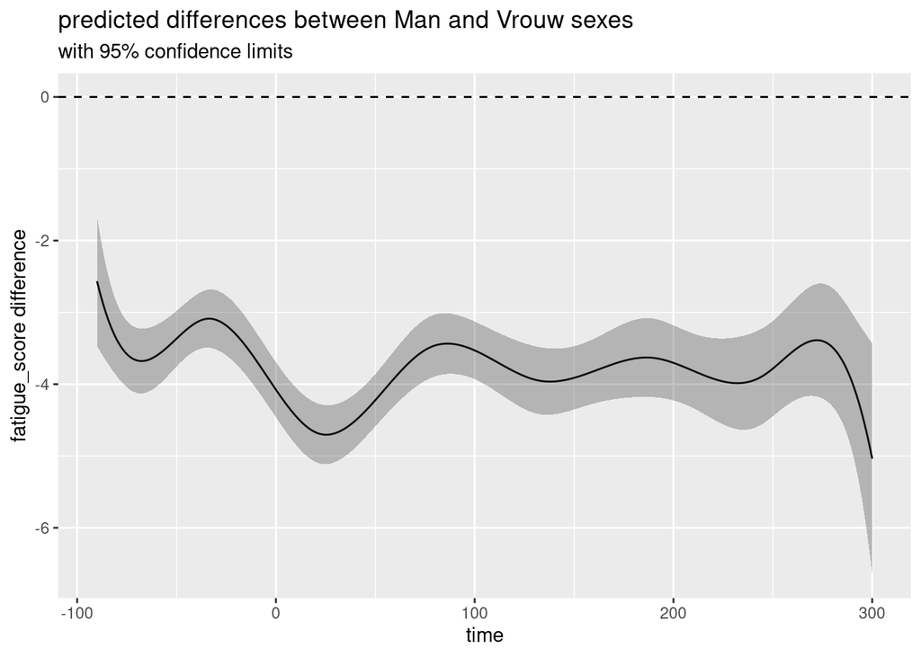

```r
# model fit with interaction between time and sex
mod_sex_gamm4 <- gamm4(
  formula = fatigue_score ~ geslacht + s(time, bs = "ps", by = geslacht),
  random = ~(1|person_id),
  REML = FALSE,
  data = VASCO_data_omicron_delta)

# create new data set
VASCO_sex_newdata <- expand_grid(
  time = -90:300
)

# linear predictor matrix for sex = Man
X_lp_man <- predict(
  object  = mod_sex_gamm4$gam,
  newdata = VASCO_sex_newdata |>
    mutate(geslacht = "Man"),
  type = "lpmatrix")

# linear predictor matrix for sex = Vrouw
X_lp_vrouw <- predict(
  object  = mod_sex_gamm4$gam,
  newdata = VASCO_sex_newdata |>
    mutate(geslacht = "Vrouw"),
  type = "lpmatrix")

# linear predictor matrix of difference
X_lp_difference <- X_lp_man - X_lp_vrouw

# coefficients of model fit
betas <- coef(mod_sex_gamm4$gam)
# variance covariance matrix
varcov <- mod_sex_gamm4$gam$Vp

# create predictions of difference over time
VASCO_sex_newdata <- VASCO_sex_newdata |>
  mutate(
    # calculate prediction of difference
    pred_difference = X_lp_difference %*% betas,
    # calculate standard errors of prediction of difference
    se_pred_difference =  (X_lp_difference %*% varcov %*% t(X_lp_difference)) |>
      diag() |>
      sqrt(),
    # calculate confidence limits of prediction of difference
    ci_lwr_pred_difference = pred_difference - 1.96 * se_pred_difference,
    ci_upr_pred_difference = pred_difference + 1.96 * se_pred_difference)

# visualize predicted differences
ggplot(
  data = VASCO_sex_newdata,
  mapping = aes(x = time, y = pred_difference)
) +
  # add predictions
  geom_line() +
  # add confidence bands
  geom_ribbon(
    mapping = aes(
      ymin = ci_lwr_pred_difference,
      ymax = ci_upr_pred_difference),
    alpha = .3) +
  # add reference line at 0
  geom_hline(yintercept = 0, linetype = 2) +
  # add annotations
  labs(
    title ="predicted differences between Man and Vrouw sexes",
    subtitle = "with 95% confidence limits",
    y = "fatigue_score difference"
  )
```

Scripts can be found [here](https://gitl01-int-p.rivm.nl/schippem/mimic_trendspotter/).